# Bibliography Report

- [IAS Bibliography](https://www.zotero.org/groups/2352922)
- [This Report](https://ipbes-data.github.io/IPBES.LiteratureReport/output/IPBES.IAS.bibliography_report.html)
- [Github repository](https://github.com/IPBES-Data/IPBES.LiteratureReport/tree/main)

# Introduction

This report assesses the [IAS Bibliography](https://www.zotero.org/groups/2352922) in regards to different measures and shows some information of the content. It does **not** assess the content of the sources but rather the bibliometric data.

# Cleanliness of the Bibliography

Cleanliness of a bibliography is defined here as the quality of the bibliografic data in the bibliography. It does not concern any topical measures, only measures related to the bibliografic data in the bibliography.

The analysis is at the moment only done for DOIs as corresponding measures are not available at the moment for ISBNs and ISSNs and duplicate ISBNs and ISSNs can be rcorrect as div=fferent chapters of a book might be in the bibliography.

## Entries with DOIs, ISBNs or ISSNs in Zotero

To identify a reference, the most widely used identifier is the DOI. The following table shows the number of references with a DOI and the number of unique DOIs.

To consider duplicate ISBNs or ISSNs as duplicates entries in the library is not waranted as e.g. differenc chapters of a book can be separate entries in the library and therefore lead to duplicates.

- **DOIs**: 3863 (73.58%) - 4 duplicates
- **ISBNss**: 453 (8.63%) - 93 duplicates
- **ISBNss**: 3301 (62.88%) - 2559 duplicates

## DOIs in Zotero

The foilowing sections provide some more detailed analysis of the bibliography in Zenodo. The tables all contain clickable links which, shwen clicked, show the respective article in the Zotero bibliograpohy.

### Duplicates

The following DOIs are duplicates in the bibliography. This table should be empty.

```r
#|
data.frame(
  doi = bib_data$metrics$zotero_dois$duplicate,
  link = paste0(bib_data$bibliography$url, "/items/", names(bib_data$metrics$zotero_dois$duplicate))
) |>
  dplyr::mutate(
    doi = paste0('<a href="', link, '" target="_blank">', doi, "</a>"),
    link = NULL
  ) |>
  knitr::kable(
    caption = "DOIs in Zenodo which are duplicated",
    escape = FALSE
  )
```

DOIs in Zenodo which are duplicated

|  | doi |
| --- | --- |
| ERCRVI2L | [10.1111/mam.12277](https://www.zotero.org/groups/2352922/items/ERCRVI2L) |
| DNQGDYCT | [10.1111/emr.12464](https://www.zotero.org/groups/2352922/items/DNQGDYCT) |
| BKJZTSZS | [10.1111/emr.12464](https://www.zotero.org/groups/2352922/items/BKJZTSZS) |
| BW28LAD5 | [10.1111/mam.12277](https://www.zotero.org/groups/2352922/items/BW28LAD5) |

### Non Standard

All DOIs should be given as only the DOI without the resolver, i.e. `not starting with`http`. The following table shows all entries which do have a non-copnform DOI:

```r
#|

http <- grep("http", bib_data$metrics$zotero_dois$id_raw)
data.frame(
  doi = bib_data$metrics$zotero_dois$id_raw[http],
  link = paste0(bib_data$bibliography$url, "/items/", names(bib_data$metrics$zotero_dois$id_raw)[http])
) |>
  dplyr::mutate(
    doi = paste0('<a href="', link, '" target="_blank">', doi, "</a>"),
    link = NULL
  ) |>
  knitr::kable(
    caption = "DOIs in Zenodo which include a `http`",
    escape = FALSE
  )
```

DOIs in Zenodo which include a `http`

|  | doi |
| --- | --- |
| 4JHQ9XWE | [https://doi.org/10.1111/j.1461-0248.2007.01067.x](https://www.zotero.org/groups/2352922/items/4JHQ9XWE) |
| GYGADVID | [http://dx.doi.org/10.3354/meps243111](https://www.zotero.org/groups/2352922/items/GYGADVID) |
| QAYJCMTF | [https://doi.org/10.1111/jbi.13555](https://www.zotero.org/groups/2352922/items/QAYJCMTF) |
| IS3C3LLP | [http://dx.doi.org/10.3897/neobiota.25.8613](https://www.zotero.org/groups/2352922/items/IS3C3LLP) |
| UYIEZBW4 | [https://doi.org/10.1007/978-3-540-36920-2_20](https://www.zotero.org/groups/2352922/items/UYIEZBW4) |
| PV4Q78VY | [https://doi.org/10.1016/j.tree.2011.06.013](https://www.zotero.org/groups/2352922/items/PV4Q78VY) |
| P7YMTFFE | [https://doi.org/10.1890/1540-9295(2004)002[0131:BBWAAO]2.0.CO;2](https://www.zotero.org/groups/2352922/items/P7YMTFFE) |
| LIACFMQL | [https://doi.org/10.3896/IBRA.1.50.1.02](https://www.zotero.org/groups/2352922/items/LIACFMQL) |
| BZ9DZNAB | [https://doi.org/10.1080/13657305.2021.1896604](https://www.zotero.org/groups/2352922/items/BZ9DZNAB) |
| WXJ7MDE7 | [https://doi.org/10.17161/randa.v23i2.14119](https://www.zotero.org/groups/2352922/items/WXJ7MDE7) |
| JVWAGNEX | [https://doi.org/10.1126/science.336.6085.1102-b](https://www.zotero.org/groups/2352922/items/JVWAGNEX) |
| XPGMAJNK | [https://doi.org/10.1002/ffej.10044](https://www.zotero.org/groups/2352922/items/XPGMAJNK) |
| 5FMI7RIF | [https://doi.org/10.1002/aqc.1129](https://www.zotero.org/groups/2352922/items/5FMI7RIF) |
| VR7RJBFJ | [https://doi.org/10.1016/j.gecco.2020.e01080](https://www.zotero.org/groups/2352922/items/VR7RJBFJ) |
| 33P9295H | [https://doi.org/10.2307/40203478](https://www.zotero.org/groups/2352922/items/33P9295H) |
| YMQJX4SW | [https://doi.org/10.15517/rbt.v62i4.13231](https://www.zotero.org/groups/2352922/items/YMQJX4SW) |
| EECUYPAW | [https://doi.org/10.1016/j.biocon.2013.11.003](https://www.zotero.org/groups/2352922/items/EECUYPAW) |
| ELAF7FIV | [https://doi.org/10.3897/neobiota.61.58380](https://www.zotero.org/groups/2352922/items/ELAF7FIV) |
| 8D9H2WHY | [https://doi.org/10.1007/s10530-011-9946-5](https://www.zotero.org/groups/2352922/items/8D9H2WHY) |
| 3MWGCWSD | [https://doi.org/10.1016/j.cosust.2015.05.008](https://www.zotero.org/groups/2352922/items/3MWGCWSD) |
| RDSZSNGU | [http://dx.doi.org/10.1016/j.landurbplan.2016.01.007](https://www.zotero.org/groups/2352922/items/RDSZSNGU) |
| DRNCYUQ5 | [https://doi.org/10.1111/j.1472-4642.2010.00652.x](https://www.zotero.org/groups/2352922/items/DRNCYUQ5) |
| 5NAEENVG | [https://doi.org/10.3389/fevo.2020.576667](https://www.zotero.org/groups/2352922/items/5NAEENVG) |
| NBUJ6447 | [https://doi.org/10.1111/1365-2745.13419](https://www.zotero.org/groups/2352922/items/NBUJ6447) |
| SHBVHJRC | [https://doi.org/10.1016/j.biocontrol.2020.104503](https://www.zotero.org/groups/2352922/items/SHBVHJRC) |
| GFLFSATK | [https://doi.org/10.1079/cabireviews202217006](https://www.zotero.org/groups/2352922/items/GFLFSATK) |
| SXSCHIRC | [https://doi.org/10.1007/s11600-018-0237-8](https://www.zotero.org/groups/2352922/items/SXSCHIRC) |
| ZHZCEETV | [https://doi.org/10.11646/zootaxa.5039.4.7](https://www.zotero.org/groups/2352922/items/ZHZCEETV) |
| K5U3QNCX | [https://doi.org/10.2305/IUCN.CH.2019.SSC-OP.62.en](https://www.zotero.org/groups/2352922/items/K5U3QNCX) |
| YI5G6YAS | [https://doi.org/10.1111/mam.12176](https://www.zotero.org/groups/2352922/items/YI5G6YAS) |

[output cut: 170 more lines]

### Not Valid

```r
#|

data.frame(
  doi = bib_data$metrics$zotero_dois$not_valid,
  link = paste0(bib_data$bibliography$url, "/items/", names(bib_data$metrics$zotero_dois$not_valid))
) |>
  dplyr::mutate(
    doi = paste0('<a href="', link, '" target="_blank">', doi, "</a>"),
    link = NULL
  ) |>
  knitr::kable(
    caption = "DOIs in Zenodo which ar not valid",
    escape = FALSE
  )
```

DOIs in Zenodo which ar not valid

|  | doi |
| --- | --- |
| 36NKRZYZ | [10.1641/0006-3568(2002)052[0801:EEIINA]2.0.CO;2](https://www.zotero.org/groups/2352922/items/36NKRZYZ) |
| P7YMTFFE | [10.1890/1540-9295(2004)002[0131:BBWAAO]2.0.CO;2](https://www.zotero.org/groups/2352922/items/P7YMTFFE) |
| 8TEITQDU | [10.1659/0276-4741(2006)026[0080:MANRNC]2.0.CO;2](https://www.zotero.org/groups/2352922/items/8TEITQDU) |
| 836VV7XI | [10.1641/0006-3568(2000)050[0239:TAGISF]2.3.CO;2](https://www.zotero.org/groups/2352922/items/836VV7XI) |
| XBI9ZZ3B | [10.1890/1540-9295(2005)003[0103:TTOTCR]2.0.CO;2](https://www.zotero.org/groups/2352922/items/XBI9ZZ3B) |
| FWA4CJD8 | [10.1890/1540-9295(2006)004[0075:EACUDO]2.0.CO;2](https://www.zotero.org/groups/2352922/items/FWA4CJD8) |
| NC4C4UVR | [10.1641/0006-3568(2002)052[0464:Tgohnc]2.0.Co;2](https://www.zotero.org/groups/2352922/items/NC4C4UVR) |
| NYTDRNS8 | [10.1890/1051-0761(2006)016[2035:BIRFUP]2.0.CO;2](https://www.zotero.org/groups/2352922/items/NYTDRNS8) |
| FF5QVLTE | [10.2111/1551-5028(2007)60[225:KAITPO]2.0.CO;2](https://www.zotero.org/groups/2352922/items/FF5QVLTE) |
| RF6KDAH8 | [10.1890/1051-0761(2000)010[0689:BICEGC]2.0.CO;2](https://www.zotero.org/groups/2352922/items/RF6KDAH8) |
| T4GQDS4Y | [10.1890/1051-0761(2002)012[0927:AAMIIP]2.0.CO;2](https://www.zotero.org/groups/2352922/items/T4GQDS4Y) |
| QJUH6JCE | [10.1579/0044-7447(2008)37[114:ECITBS]2.0.CO;2](https://www.zotero.org/groups/2352922/items/QJUH6JCE) |
| SVAUY7BQ | [10.1641/0006-3568(2004)054[0613:TGISIN]2.0.CO;2](https://www.zotero.org/groups/2352922/items/SVAUY7BQ) |
| PJ2U42NU | [10.1641/0006-3568(2001)051[0095:HAGPDG]2.0.CO;2](https://www.zotero.org/groups/2352922/items/PJ2U42NU) |
| X4PQSSSS | [10.1890/1540-9295(2005)003[0071:BCOIAP]2.0.CO;2](https://www.zotero.org/groups/2352922/items/X4PQSSSS) |
| SWNQTRGB | [10.1614/0043-1745(2003)051[0247:EPIATO]2.0.CO;2](https://www.zotero.org/groups/2352922/items/SWNQTRGB) |
| QMUJCAI5 | [10.4102/koedoe. v53i2.1049](https://www.zotero.org/groups/2352922/items/QMUJCAI5) |
| YGZUYIXA | [10.2981/0909-6396(2007)13[159:PCOCMC]2.0.CO;2](https://www.zotero.org/groups/2352922/items/YGZUYIXA) |
| RHMHM7QA | [10.1614/0043-1745(2000)048[0255:IWIRSI]2.0.CO;2](https://www.zotero.org/groups/2352922/items/RHMHM7QA) |
| NZTBD2B9 | [10.1890/1540-9295(2006)4[428:LFAMIT]2.0.CO;2](https://www.zotero.org/groups/2352922/items/NZTBD2B9) |
| QHVGP3F6 | [10.1002/(SICI)1096-9063(199703)49:3%3C213::AID-PS516%3E3.0.CO;2-%23](https://www.zotero.org/groups/2352922/items/QHVGP3F6) |
| 9NMFEPRL | [10.1641/0006-3568(2004)054[0337:DDPBWF]2.0.CO;2](https://www.zotero.org/groups/2352922/items/9NMFEPRL) |
| C6YEVH8M | [10.1641/0006-3568(2002)052[0593:BMTACA]2.0.CO;2](https://www.zotero.org/groups/2352922/items/C6YEVH8M) |
| PLG2LPDR | [10.1641/0006-3568(2006)56[931:SAEITM]2.0.CO;2](https://www.zotero.org/groups/2352922/items/PLG2LPDR) |
| FAWZTUAE | [10.1890/1051-0761(2002)012[0618:ATATOU]2.0.CO;2](https://www.zotero.org/groups/2352922/items/FAWZTUAE) |
| P3WI2WYU | [10.1890/1540-9295(2005)003[0012:ISPMAF]2.0.CO;2](https://www.zotero.org/groups/2352922/items/P3WI2WYU) |
| UR2MRQQM | [10.1653/0015-4040(2007)90[723:AOOTRI]2.0.CO;2](https://www.zotero.org/groups/2352922/items/UR2MRQQM) |
| QZ7UTL49 | [10.1641/0006-3568(2000)050[0053:EAECON]2.3.CO;2](https://www.zotero.org/groups/2352922/items/QZ7UTL49) |
| ACLGWPX2 | [10.1890/0012-9658(2006)87[3109:CDGIAL]2.0.CO;2](https://www.zotero.org/groups/2352922/items/ACLGWPX2) |
| P67U9S2X | [https://conbio.onlinelibrary.wiley.com/doi/epdf/10.1111/j.1755-263X.2011.00164.x](https://www.zotero.org/groups/2352922/items/P67U9S2X) |
| 2GFWIKC9 | [https://link.springer.com/article/10.1007/s10530-012-0347-1](https://www.zotero.org/groups/2352922/items/2GFWIKC9) |
| Y3V965JT | [10.1002/1522-2632(200011)85:5/6<609::AID-IROH609>3.0.CO;2-S](https://www.zotero.org/groups/2352922/items/Y3V965JT) |
| 9RKURUXK | [10.1641/0006-3568(2003)053[0703:BAFSIT]2.0.CO;2](https://www.zotero.org/groups/2352922/items/9RKURUXK) |
| R7GPGV9H | [doi.org/10.2307/1311536](https://www.zotero.org/groups/2352922/items/R7GPGV9H) |
| PJSTT35V | [10.1641/0006-3568(2004)054[0321:TGDONM]2.0.CO;2](https://www.zotero.org/groups/2352922/items/PJSTT35V) |
| GNG7XTF6 | [https://www.sciencedirect.com/science/article/abs/pii/S0169534709002018](https://www.zotero.org/groups/2352922/items/GNG7XTF6) |
| IFS8U8R3 | [10.1890/0012-9658(1999)080[2045:SLRACF]2.0.CO;2](https://www.zotero.org/groups/2352922/items/IFS8U8R3) |
| EAY98IYC | [10.1029/2011GL046583@10.1002/(ISSN)1944-8007.GRL40](https://www.zotero.org/groups/2352922/items/EAY98IYC) |
| NHW5MM48 | [doi.org/10.1023/A:1010090414598](https://www.zotero.org/groups/2352922/items/NHW5MM48) |
| XBMBJM6T | [doi.org/10.1038/26886](https://www.zotero.org/groups/2352922/items/XBMBJM6T) |
| EGLBHEW9 | [10.1890/1540-9295(2007)5[365:ANGOCE]2.0.CO;2](https://www.zotero.org/groups/2352922/items/EGLBHEW9) |
| ABXB2YE3 | [10.1371/ journal.pone.0111913](https://www.zotero.org/groups/2352922/items/ABXB2YE3) |
| HU5AB4ZR | [10.1093/aobpla/plv085](https://www.zotero.org/groups/2352922/items/HU5AB4ZR) |
| DVSZLWH6 | [10.1641/0006-3568(2005)055[0518:DRFIIL]2.0.CO;2](https://www.zotero.org/groups/2352922/items/DVSZLWH6) |
| FYJYPZ7I | [annurev.es.23.110192.000431](https://www.zotero.org/groups/2352922/items/FYJYPZ7I) |
| MEWWU4ZQ | [10.1111/j.1744-7429.201 0.00647.x](https://www.zotero.org/groups/2352922/items/MEWWU4ZQ) |
| LWE6PBMS | [10.1641/0006-3568(2004)054[0677:EOIAPO]2.0.CO;2](https://www.zotero.org/groups/2352922/items/LWE6PBMS) |
| H3NKGIYL | [10.1890/1540-9295(2003)001[0197:SODECA]2.0.CO;2](https://www.zotero.org/groups/2352922/items/H3NKGIYL) |
| B4LKGDYS | [10.1577/1548-8667(2000)012<0001:IVIAIP>2.0.CO;2](https://www.zotero.org/groups/2352922/items/B4LKGDYS) |
| SCATM7WD | [10.1645/0022-3395(2001)087[1366:TSNACI]2.0.CO;2](https://www.zotero.org/groups/2352922/items/SCATM7WD) |
| JC88EUMS | [10.2983/0730-8000(2007)26[281:BAAESA]2.0.CO;2](https://www.zotero.org/groups/2352922/items/JC88EUMS) |
| 6MV3NVAM | [10.1890/1051-0761(2001)011[1750:ESITIS]2.0.CO;2](https://www.zotero.org/groups/2352922/items/6MV3NVAM) |
| 78WHBLJ3 | [10.1002/(SICI)1099-145X(199905/06)10:3<225::AID-LDR337>3.0.CO;2-T](https://www.zotero.org/groups/2352922/items/78WHBLJ3) |
| 8VEWQWK3 | [10.1659/0276-4741(2002)022[0159:IOPPOS]2.0.CO;2](https://www.zotero.org/groups/2352922/items/8VEWQWK3) |
| ELNKKYYQ | [10.1641/0006-3568(2003)053[0843:AMEASP]2.0.CO;2](https://www.zotero.org/groups/2352922/items/ELNKKYYQ) |
| G7F5FTVW | [10.2984/1534-6188(2007)61[469:rroaao]2.0.co;2](https://www.zotero.org/groups/2352922/items/G7F5FTVW) |
| MIV6DY5E | [10.1890/1540-9295(2007)5[199:IASIAE]2.0.CO;2](https://www.zotero.org/groups/2352922/items/MIV6DY5E) |
| GEAP9FT6 | [10.1641/0006-3568(2001)051[0103:HAAPOI]2.0.CO;2](https://www.zotero.org/groups/2352922/items/GEAP9FT6) |
| U97B2QGL | [10.1641/0006-3568(2005)055[0780:TOOTNP]2.0.CO;2](https://www.zotero.org/groups/2352922/items/U97B2QGL) |
| KSWSHRIZ | [10.1890/1540-9295(2003)001[0307:BBAB]2.0.CO;2](https://www.zotero.org/groups/2352922/items/KSWSHRIZ) |
| 3YHUAZSW | [10.1641/0006-3568(2005)055[0335:SPFRTT]2.0.CO;2](https://www.zotero.org/groups/2352922/items/3YHUAZSW) |
| AP6PDDCR | [10.1890/1540-9295(2005)003[0495:TWOTRD]2.0.CO;2](https://www.zotero.org/groups/2352922/items/AP6PDDCR) |
| ZEML3VIC | [10.2984/1534-6188(2007)61[307:BAIOPI]2.0.CO;2](https://www.zotero.org/groups/2352922/items/ZEML3VIC) |
| Z64YL7WL | [10.1890/1540-9295(2007)5[153:IPIIAR]2.0.CO;2](https://www.zotero.org/groups/2352922/items/Z64YL7WL) |
| FWWQ8TZG | [10.1890/1540-9295(2004)002[0354:APFASI]2.0.CO;2](https://www.zotero.org/groups/2352922/items/FWWQ8TZG) |
| K55B5YBI | [10.1890/1540-9295(2004)002[0265:TOOATI]2.0.CO;2](https://www.zotero.org/groups/2352922/items/K55B5YBI) |

### Not in [OpenAlex](https://OpenAlex.org)

To validate the existence and validity of the DOIs, we check if the DOIs are in the [OpenAlex](https://OpenAlex.org) database.

```r
data.frame(
  doi = bib_data$metrics$zotero_dois$not_in_oa,
  link = paste0(bib_data$bibliography$url, "/items/", names(bib_data$metrics$zotero_dois$not_in_oa))
) |>
  dplyr::mutate(
    doi = paste0('<a href="', link, '" target="_blank">', doi, "</a>"),
    link = NULL
  ) |>
  knitr::kable(
    caption = "DOIs in Zenodo which ar not in [OpenAlex](https://OpenAlex.org)",
    escape = FALSE
  )
```

DOIs in Zenodo which ar not in [OpenAlex](https://OpenAlex.org)

|  | doi |
| --- | --- |
| 36NKRZYZ | [10.1641/0006-3568(2002)052[0801:EEIINA]2.0.CO;2](https://www.zotero.org/groups/2352922/items/36NKRZYZ) |
| 4JHQ9XWE | [10.1111/j.1461-0248.2007.01067.x](https://www.zotero.org/groups/2352922/items/4JHQ9XWE) |
| GYGADVID | [10.3354/meps243111](https://www.zotero.org/groups/2352922/items/GYGADVID) |
| 3XCCATCT | [10.2111/REM-D-09-00151.1](https://www.zotero.org/groups/2352922/items/3XCCATCT) |
| YBIQ59C7 | [10.1111/j.1365-294X.2011.05432.x](https://www.zotero.org/groups/2352922/items/YBIQ59C7) |
| 96JMLEEB | [10.3197/096327114X13947900181031](https://www.zotero.org/groups/2352922/items/96JMLEEB) |
| FH3FMGIH | [10.1111/2041-210X.12844](https://www.zotero.org/groups/2352922/items/FH3FMGIH) |
| A4YQWPZU | [10.5281/ZENODO.5562892](https://www.zotero.org/groups/2352922/items/A4YQWPZU) |
| AGJPTGIV | [10.1017/S0032247414000916](https://www.zotero.org/groups/2352922/items/AGJPTGIV) |
| FCVNL7LU | [10.1111/j.1466-822X.2006.00212.x](https://www.zotero.org/groups/2352922/items/FCVNL7LU) |
| Q8M8CBR8 | [10.5751/ES-11583-250318](https://www.zotero.org/groups/2352922/items/Q8M8CBR8) |
| XIF4ZMCZ | [10.1007/BF01579651](https://www.zotero.org/groups/2352922/items/XIF4ZMCZ) |
| I2E6MVQB | [10.5751/ES-09487-220401](https://www.zotero.org/groups/2352922/items/I2E6MVQB) |
| 9XIKAMDJ | [10.1023/A:1014193329979](https://www.zotero.org/groups/2352922/items/9XIKAMDJ) |
| ERERLZTN | [10.5281/ZENODO.5719431](https://www.zotero.org/groups/2352922/items/ERERLZTN) |
| 9IYXL4BB | [10.1080/0376835X.2011.570065](https://www.zotero.org/groups/2352922/items/9IYXL4BB) |
| GKRHU9XM | [10.1017/S003060531200124X](https://www.zotero.org/groups/2352922/items/GKRHU9XM) |
| 5FYKRWIE | [10.1016/S2542-5196(19)30194-9](https://www.zotero.org/groups/2352922/items/5FYKRWIE) |
| QAYJCMTF | [10.1111/jbi.13555](https://www.zotero.org/groups/2352922/items/QAYJCMTF) |
| QU5GAXV3 | [10.7882/AZ.2006.016](https://www.zotero.org/groups/2352922/items/QU5GAXV3) |
| MV84B6PD | [10.1017/S0376892907003815](https://www.zotero.org/groups/2352922/items/MV84B6PD) |
| D66YXVTW | [10.1134/S2075111711040059](https://www.zotero.org/groups/2352922/items/D66YXVTW) |
| 2ELAFJ42 | [10.3362/2041-7136.2010.014](https://www.zotero.org/groups/2352922/items/2ELAFJ42) |
| S9UT4YR2 | [10.1017/S0376892908005146](https://www.zotero.org/groups/2352922/items/S9UT4YR2) |
| GXMVVJX3 | [10.1094/PHYTO-105-7-0001](https://www.zotero.org/groups/2352922/items/GXMVVJX3) |
| IS3C3LLP | [10.3897/neobiota.25.8613](https://www.zotero.org/groups/2352922/items/IS3C3LLP) |
| NAKFCHZ4 | [10.1016/B978-0-444-52272-6.00528-6](https://www.zotero.org/groups/2352922/items/NAKFCHZ4) |
| QZVRPZ7E | [10.1007/BF01867529](https://www.zotero.org/groups/2352922/items/QZVRPZ7E) |
| UYIEZBW4 | [10.1007/978-3-540-36920-2_20](https://www.zotero.org/groups/2352922/items/UYIEZBW4) |
| EGGVZ36N | [10.1111/j.1365-294X.2012.05710.x](https://www.zotero.org/groups/2352922/items/EGGVZ36N) |

[output cut: 617 more lines]

### TODO Do Exist

TODO Finally we check, if these dois exist but are not ingested into OpanAlex. This is done using the `doi.org` resolver This is disabled at the moment and still needs o=to be implemented.

# Bibliographic analysis

In the bibliographic analysis, we can only analyse the references in [OpenAlex](https://OpenAlex.org) as the bibliographic metadata alanised is not in the Zotero liubrary but retrieved from [OpenAlex](https://OpenAlex.org).

## Publication types

Works on Zenodo as well as on [OpenAlex](https://OpenAlex.org) are of different types. Here we show these separate.

```r
bib_data$figure_types_data |>
  dplyr::arrange(
    from,
    desc(count)
  ) |>
  knitr::kable(
    caption = "Types of documents from the Zotero bibliography as well as from OpenApex."
  )
```

Types of documents from the Zotero bibliography as well as from OpenApex.

| type | count | from |
| --- | --- | --- |
| article | 3423 | OpenAlex |
| review | 119 | OpenAlex |
| preprint | 13 | OpenAlex |
| dataset | 10 | OpenAlex |
| book-chapter | 6 | OpenAlex |
| book | 2 | OpenAlex |
| other | 2 | OpenAlex |
| journalArticle | 4157 | Zotero |
| bookSection | 305 | Zotero |
| book | 244 | Zotero |
| report | 236 | Zotero |
| webpage | 97 | Zotero |
| conferencePaper | 83 | Zotero |
| document | 67 | Zotero |
| annotation | 19 | Zotero |
| thesis | 15 | Zotero |
| dataset | 12 | Zotero |
| blogPost | 9 | Zotero |
| preprint | 2 | Zotero |
| magazineArticle | 1 | Zotero |
| newspaperArticle | 1 | Zotero |
| presentation | 1 | Zotero |
| videoRecording | 1 | Zotero |

[figure not shown]

```r
bib_data$figure_types
```

### Zenodo versus [OpenAlex](https://OpenAlex.org) Types

The types entered in the Zenodo library and the types as retrieved from [OpenAlex](https://OpenAlex.org) are not linked, therefore they can differ, This can indicate problems but not necessarily has to. These cases need to be carefully evaluated and here only a starting point is given.

`NA` in [OpenAlex](https://OpenAlex.org) is likely caused by the doi not found in [OpenAlex](https://OpenAlex.org) (not in there, not valid, non-standard DOI in Zenodo). `NA` in Zotero is linked to non-standard DOI entries (i.e. with `http`) whcih can therefore not be linked to [OpenAlex](https://OpenAlex.org) data. If all DOIs are in standard format, there should be no NAs in this Table in the column Ferom Zenodo.

Improvements should be done after feedback.

```r
bib_data$metrics$types$comparison |>
  knitr::kable(
    col.names = c("Type from Zenodo", "Type from [OpenAlex](https://OpenAlex.org)", "count"),
    caption = "Table giving the combination of types from Zenodo as well as [OpenAlex](https://OpenAlex.org) and their frequency"
  )
```

Table giving the combination of types from Zenodo as well as [OpenAlex](https://OpenAlex.org) and their frequency

| Type from Zenodo | Type from [OpenAlex](https://OpenAlex.org) | count |
| --- | --- | --- |
| journalArticle | article | 3081 |
| journalArticle | NA | 952 |
| NA | article | 339 |
| bookSection | NA | 305 |
| book | NA | 244 |
| report | NA | 236 |
| journalArticle | review | 111 |
| webpage | NA | 97 |
| conferencePaper | NA | 74 |
| document | NA | 67 |
| annotation | NA | 19 |
| thesis | NA | 15 |
| dataset | NA | 12 |
| blogPost | NA | 9 |
| journalArticle | preprint | 8 |
| NA | dataset | 8 |
| NA | review | 8 |
| conferencePaper | article | 5 |
| conferencePaper | book-chapter | 3 |
| preprint | preprint | 2 |
| journalArticle | dataset | 2 |
| journalArticle | other | 2 |
| journalArticle | book | 2 |
| NA | book-chapter | 2 |
| NA | preprint | 2 |
| presentation | NA | 1 |
| videoRecording | NA | 1 |
| journalArticle | book-chapter | 1 |
| magazineArticle | NA | 1 |
| conferencePaper | preprint | 1 |
| newspaperArticle | NA | 1 |

## Year of Publication

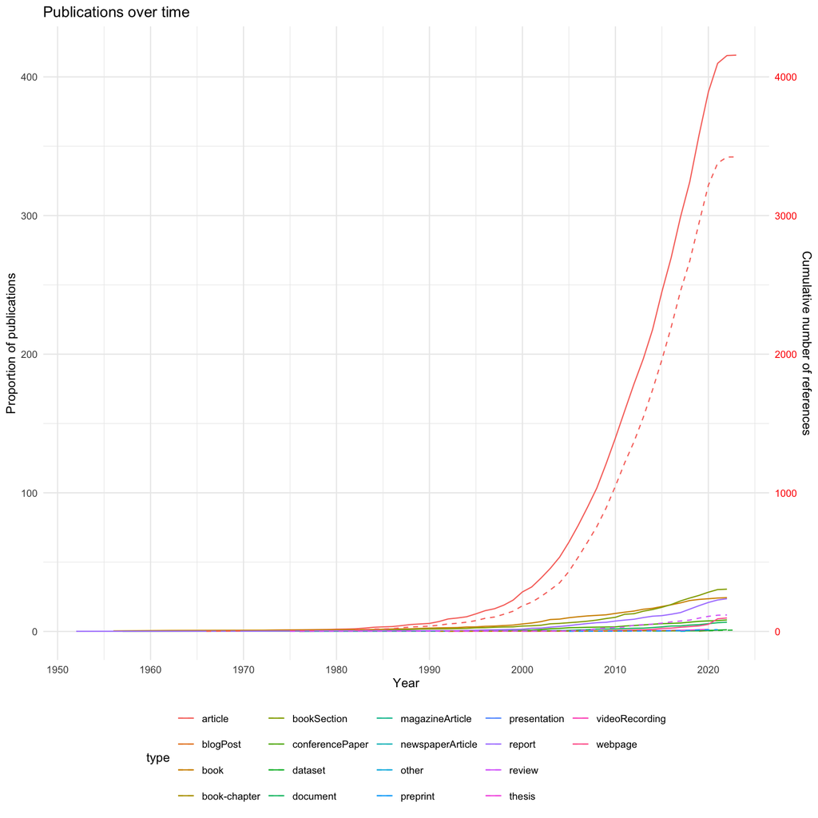

```r
bib_data$figure_pub_year
```

## Access Status of References

This is checked by using the [OpenAlex](https://OpenAlex.org) retrieved works. Therefore it is li=mited to the works that are on [OpenAlex](https://OpenAlex.org). At the moment, only references with a DOI were retrieved from [OpenAlex](https://OpenAlex.org).

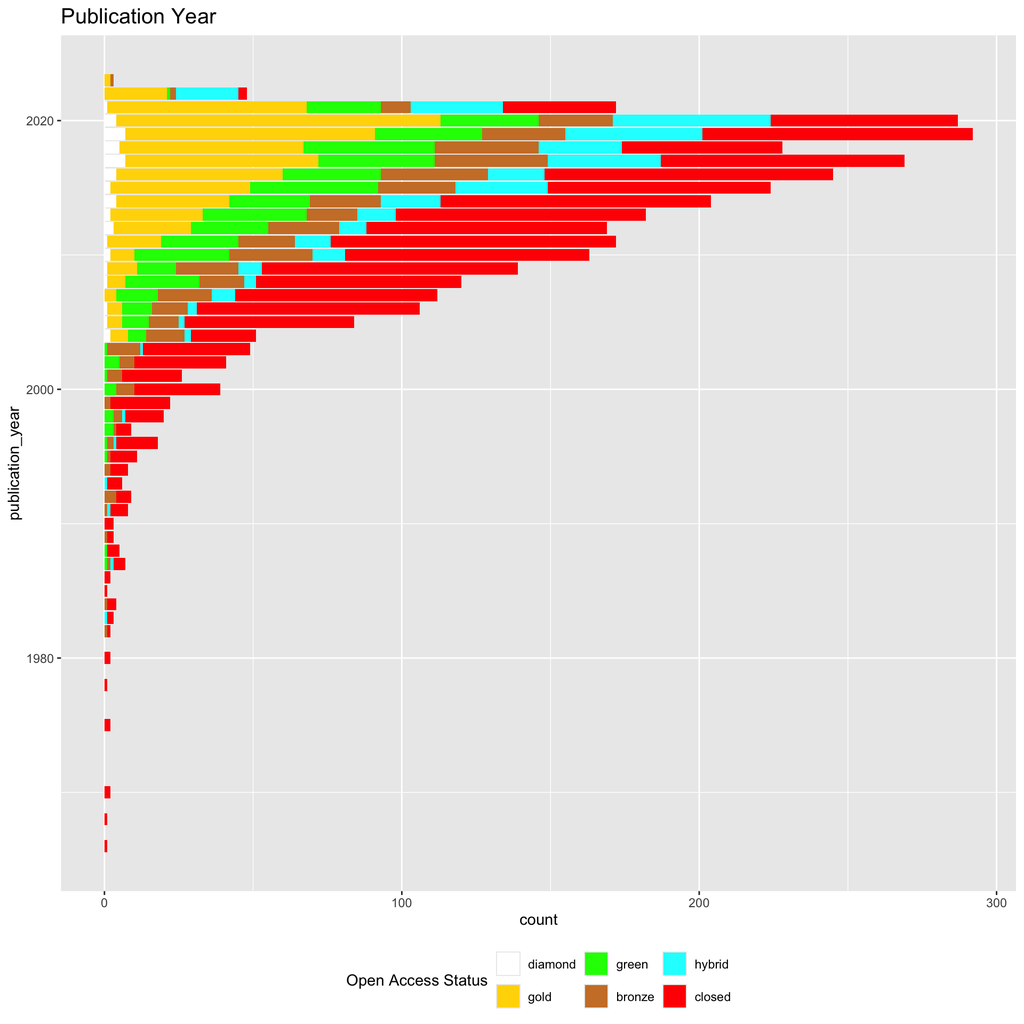

```r
bib_data$figure_oa_status
```

## 50 Most often cited Journals

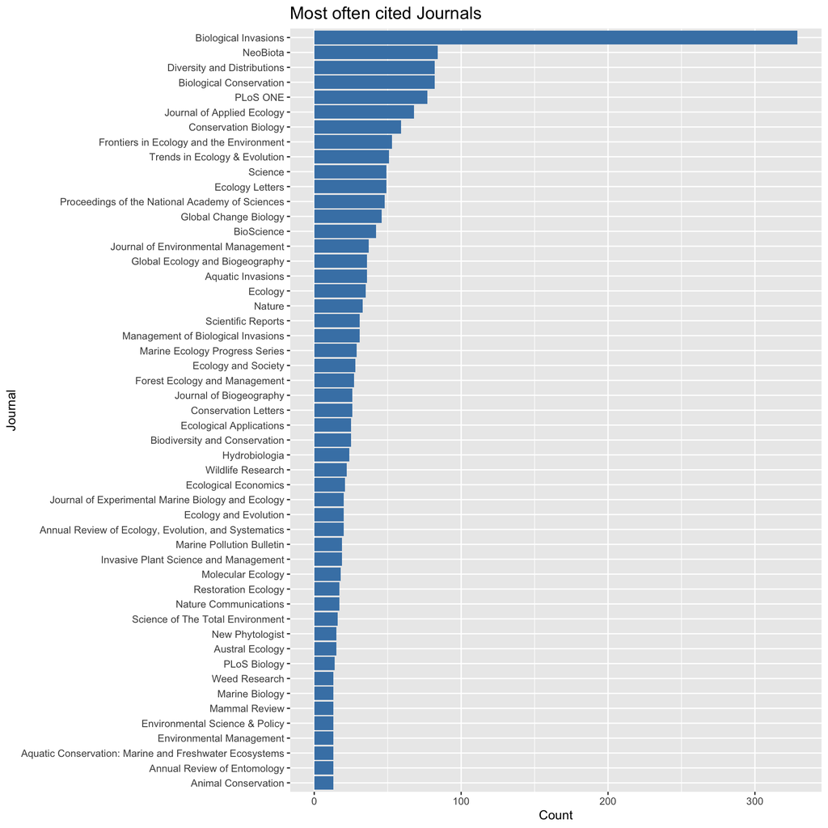

```r
bib_data$figure_top_journals
```

```r
bib_data$figure_top_journals_data |>
  IPBES.R::table_dt("cited_journals")
```

|  | Journal | count |
| --- | --- | --- |
| 1 | Biological Invasions | 329 |
| 2 | NeoBiota | 84 |
| 3 | Biological Conservation | 82 |
| 4 | Diversity and Distributions | 82 |
| 5 | PLoS ONE | 77 |
| 6 | Journal of Applied Ecology | 68 |
| 7 | Conservation Biology | 59 |
| 8 | Frontiers in Ecology and the Environment | 53 |
| 9 | Trends in Ecology & Evolution | 51 |
| 10 | Ecology Letters | 49 |

[output cut: 41 more lines]

## TODO Coutries of Institutes of all authors

```r
#|
#| fig-height: 10
#| fig-width: 10

bib_data$figure_top_countries
```

[output not shown]

This table contains all countries and the number of authorship.

```r
bib_data$figure_top_country_data |>
  IPBES.R::table_dt("top_countries")
```

|  | Country | Count |
| --- | --- | --- |
| 1 | AM | 1 |
| 2 | AO | 1 |
| 3 | AZ | 1 |
| 4 | BB | 1 |
| 5 | BM | 1 |
| 6 | BN | 1 |
| 7 | BT | 1 |
| 8 | BY | 1 |
| 9 | BZ | 1 |
| 10 | CD | 1 |

[output cut: 134 more lines]